# Специфика медицинских данных

Ekaterina Vostokova

2024-11-03

После чтения датасата, производятся некоторые шаги для его предобработки: - Добавлена переменная hem_level, отражающая, находится ли уровень гемоглобина в пределах референса или же отличается в ту или другую сторону - Все качественные переменные переведены в факторы - Дюймы и фунты переведены в метры и килограммы, соответственно, а также переведены в количественные переменные

```r
data_init <- as_tibble(read_excel("trauma.xlsx"))
data_m <- data_init %>%
  filter(Sex == "Male") %>%
  mutate(hem_level = cut(Hb, breaks = c(-Inf, 13.5, 16, Inf), labels = c("Понижен", "В норме", "Повышен")))
data_f <- data_init %>%
  filter(Sex == "Female") %>%
  mutate(hem_level = cut(Hb, breaks = c(-Inf, 12, 14, Inf), labels = c("Понижен", "В норме", "Повышен")))
data <- rbind(data_m, data_f)
data <- data %>%
  mutate(across(where(is.character), function(x) as.factor(x)))
data <- data %>%
  mutate(Height = as.numeric(gsub("[^0-9.]", "", Height))) %>%
  mutate(Height = Height*2.54/100)
data <- data %>%
  mutate(Weight = Weight/2.2)
data
```

```
## # A tibble: 1,024 × 13
##       id Name      Sex     Age Height Weight   SBP   DBP  FOUR   GSC    Hb Death
##    <dbl> <fct>     <fct> <dbl>  <dbl>  <dbl> <dbl> <dbl> <dbl> <dbl> <dbl> <dbl>
##  1     3 Kole Cook Male     39   1.85   95.5   122   102    12    12  15       0
##  2     6 Joseph B… Male     60   1.84   91.6   118    88    13    11  15       0
##  3     8 Aaron Ed… Male     26   1.90   88.2   114    94    11    10  14.4     0
##  4    11 Joshua B… Male     35   1.86   98.6   106    86    11    10  14.5     0
##  5    14 Morgan C… Male     47   1.89   98.4   114    86    11     7  13.1     0
##  6    15 Jackson … Male     40   1.83   99.0   114    82    13    11  14.6     0
##  7    18 Dillon R… Male     34   1.85   92.4   108    84     5     5  12.3     1
##  8    19 Nicholas… Male     35   1.83  102.     98    72     7     5  14.4     0
##  9    20 Justin H… Male     47   1.76   90.2   102    74     5     4  13.8     1
## 10    22 Azamat T… Male     27   1.93   90.3   106    80     9     8  13.8     0
## # ℹ 1,014 more rows
## # ℹ 1 more variable: hem_level <fct>
```

### Задание 1. Описательные статистики и пониженный гемоглобин

Дайте описательную статистику для переменных, включённых в датасет. Дополнительно рассчитайте, у какого количества пациентов и в каком проценте случаев у пациентов был снижен уровень гемоглобина? Используйте следующие референтные значения (Мужчины: 13.5–16 г/дл, Женщины: 12–14 г/дл).

```r
data %>%
    select(Sex,
           Age,
           Height,
           Weight,
           SBP,
           DBP,
           FOUR,
           GSC,
           Hb,
           Death,
           hem_level) %>%
    tbl_summary(by = Death) %>%
    add_p()
```

| **Characteristic** | **0** N = 615<sup>1</sup> | **1** N = 409<sup>1</sup> | **p-value**<sup>2</sup> |
| --- | --- | --- | --- |
| Sex |  |  | 0.5 |
| Female | 226 (37%) | 158 (39%) |  |
| Male | 389 (63%) | 251 (61%) |  |
| Age | 40 (29, 52) | 43 (30, 53) | 0.14 |
| Height | 1.85 (1.78, 1.91) | 1.85 (1.76, 1.90) | 0.3 |
| Weight | 88 (83, 94) | 88 (82, 93) | 0.3 |
| SBP | 114 (108, 118) | 106 (102, 110) | <0.001 |
| DBP | 88 (82, 94) | 80 (76, 86) | <0.001 |
| FOUR | 10.0 (9.0, 12.0) | 6.0 (5.0, 8.0) | <0.001 |
| GSC | 9.00 (8.00, 11.00) | 5.00 (4.00, 7.00) | <0.001 |
| Hb | 13.50 (12.40, 14.30) | 12.60 (11.40, 13.30) | <0.001 |
| hem_level |  |  | <0.001 |
| Понижен | 203 (33%) | 312 (76%) |  |
| В норме | 411 (67%) | 97 (24%) |  |
| Повышен | 1 (0.2%) | 0 (0%) |  |

<sup>1</sup> n (%); Median (Q1, Q3)  
<sup>2</sup> Pearson’s Chi-squared test; Wilcoxon rank sum test; Fisher’s exact test

```r
number_lower <- length(which(data$hem_level == "Понижен"))
percent_lower <- length(which(data$hem_level == "Понижен")) / nrow(data)

output <- paste("Количество пациентов с пониженным гемоглобином:", number_lower,
                "Доля пациентов с пониженным гемоглобином:", round(percent_lower, 2)*100, "%")
print(output)
```

```
## [1] "Количество пациентов с пониженным гемоглобином: 515 Доля пациентов с пониженным гемоглобином: 50 %"
```

Следовательно, в датасете есть 515 пациентов с пониженным гемоглобином, что составляет примерно 50% от общего числа пациентов.

### Задание 2. ИМТ пациентов

Рассчитайте индекс массы тела у пациентов (кг / м2). Каков был средний (M (SD)) уровень ИМТ у пациентов, включённых в исследование? Какая доля пациентов имела ожирение (ИМТ > 30)?

```r
data <- data %>%
  mutate(IMT = as.numeric(Weight / (Height)**2))
mean_imt <- data %>%
  summarise(mean_IMT = mean(IMT),
            sd_IMT = sd(IMT))
large_imt <- data %>%
  filter(IMT > 30) %>%
  nrow()

output <- paste("Средний ИМТ:", round(mean_imt$mean_IMT, 2),
                "Стандартное отклонение:", round(mean_imt$sd_IMT, 2),
                "Доля пациентов с ИМТ больше 30:", large_imt/nrow(data)*100, "%")
print(output)
```

```
## [1] "Средний ИМТ: 26.06 Стандартное отклонение: 2.57 Доля пациентов с ИМТ больше 30: 6.93359375 %"
```

Итак, средний ИМТ в датасете составил 26.06 (sd = 2.57), а количество пациентов с ИМТ больше 30 составило 71 человек, то есть приблизительно 7%.

### Задание 3. ROC-кривая

Как выглядит ROC-кривая для предсказания летального исхода в течение 24 часов по переменной, характеризующей уровень гемоглобина? Постройте график. Чем может быть обусловлена такая форма кривой?

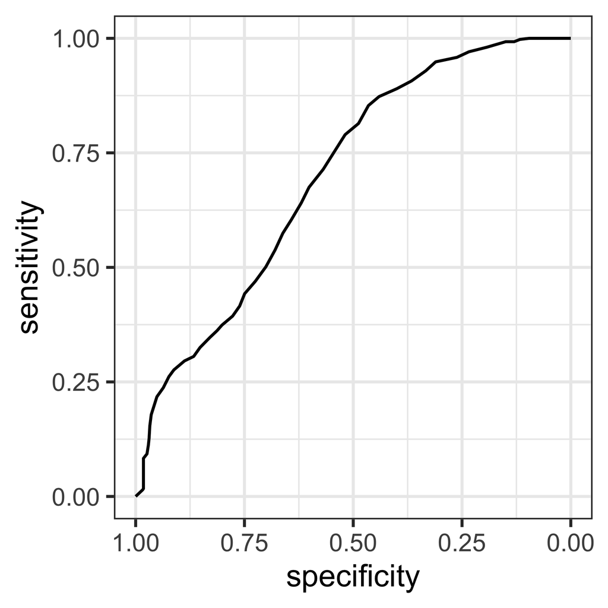

```r
roc_curve_1 <- roc(Death ~ Hb,
                   data = data)
roc_curve_1 %>%
    ggroc() +
    theme_bw()
```

Roc кривая достаточно близка к диагонали, следовательно, уровень гемоглобина не очень эффективно предсказывает наступление смерти в течение суток.

### Задание 4. Площадь под ROC-кривой

Чему равна площадь под ROC-кривой, которую вы построили в вопросе 3? Чему равен 95% двусторонний ДИ для площади под ROC-кривой, которую вы построили в вопросе 3?

```r
data %>%
  summarise(
    AUC = round(roc(Death ~ Hb, data = data)$auc, 3),
    AUC_LCL = round(roc(Death ~ Hb, data = data, ci = TRUE)$ci[1], 3),
    AUC_UCL = round(roc(Death ~ Hb, data = data, ci = TRUE)$ci[3], 3)
  )
```

```
## # A tibble: 1 × 3
##     AUC AUC_LCL AUC_UCL
##   <dbl>   <dbl>   <dbl>
## 1 0.701   0.669   0.732
```

Площадь под кривой получилась 0.70, при этом нижняя граница доверительного интервала (AUC_LCL) составляет 0.669, а верхняя (AUC_UCL) 0.732. Эти значения показывают умеренную предсказательную способность уровня гемоглобина в отношении смерти пациента в течение первых 24 часов.

### Задание 5. Летальный исход и шкала комы Глазго

Проведите ROC-анализ и определите, какое пороговое значение является оптимальным для предсказания летального исхода в течение 24 часов по шкале комы Глазго. Какой чувствительностью и специфичностью обладает данный порог?

```r
roc_curve_2 <- roc(Death ~ GSC,
                   data = data)
roc_curve_2 %>% coords(x = "best", best.method = "closest.topleft")
```

```
##   threshold specificity sensitivity
## 1       7.5   0.8081301   0.8557457
```

Для предсказания летального исхода в течение 24 часов по шкале комы Глазго оптимальный порог 7.5. При этом значении достигается максимальный баланс между специфичностью и чувствительностью, они будут составлять 0.80 и 0.85 соответственно. В целом, это достаточно хорошие показатели.

### Задание 6. Наибольшая и наименьшая площадь под ROC-кривой

Какая из количественных переменных в датасете (включая рассчитанный вами ранее ИМТ) обладает наибольшей площадью под ROC-кривой? Как вы можете интерпретировать это знание? Какая количественная переменная имеет наименьшую площадь?

```r
data %>% names()
```

```
##  [1] "id"        "Name"      "Sex"       "Age"       "Height"    "Weight"
##  [7] "SBP"       "DBP"       "FOUR"      "GSC"       "Hb"        "Death"
## [13] "hem_level" "IMT"
```

```r
data %>%
    select("Sex",
           "Age",
           "Height",
           "Weight",
           "SBP",
           "DBP",
           "FOUR",
           "GSC",
           "Hb",
           "IMT",
           "Death",
           "hem_level") %>%
    select(where(is.numeric), Death) %>%

    pivot_longer(cols = !Death) %>%

    group_by(name) %>%

    summarise(AUC = roc(Death, value, ci = T)$ci[2] %>% round(3),
              AUC_LCL = roc(Death, value, ci = T)$ci[1] %>% round(3),
              AUC_UCL = roc(Death, value, ci = T)$ci[3] %>% round(3)) %>%
    arrange(desc(AUC))
```

```
## # A tibble: 9 × 4
##   name     AUC AUC_LCL AUC_UCL
##   <chr>  <dbl>   <dbl>   <dbl>
## 1 FOUR   0.934   0.92    0.948
## 2 GSC    0.912   0.896   0.929
## 3 SBP    0.786   0.759   0.814
## 4 DBP    0.744   0.714   0.774
## 5 Hb     0.701   0.669   0.732
## 6 Age    0.527   0.491   0.563
## 7 Weight 0.518   0.482   0.554
## 8 IMT    0.502   0.465   0.538
## 9 Height 0.482   0.445   0.518
```

Наибольшая площадь под ROC-кривой у переменной FOUR (балл по шкале комы FOUR при поступлении), соответственно эта переменная наиболее точно предсказывает летальный исход у пациента. Наименьшая площадь - у роста (height), она даже меньше 0.5 (диагональ), и совершенно не обладает предсказательной способностью в отношении летального исхода за первые 24 часа.